# IA - Atividade Extra Raciocínio baseado em casos

Gileade Kelvin

## Pacotes utilizados

```r
library(here)
library(dplyr)
library(class)
library(GGally)
library(knitr)
options(scipen = 999)
```

## Importando dados

```r
cars_original <- read.csv("data.csv", stringsAsFactors = FALSE)
```

O conjunto de dados usado nesta atividade consiste em 11914 observações que detalham carros em 16 variáveis. Citadas a seguir:

```r
colnames(cars_original)
```

```
##  [1] "Make"              "Model"             "Year"
##  [4] "Engine.Fuel.Type"  "Engine.HP"         "Engine.Cylinders"
##  [7] "Transmission.Type" "Driven_Wheels"     "Number.of.Doors"
## [10] "Market.Category"   "Vehicle.Size"      "Vehicle.Style"
## [13] "highway.MPG"       "city.mpg"          "Popularity"
## [16] "MSRP"
```

A maioria destas variáveis têm nomes autoexplicativos mas vale destacar que MSRP é o preço do carro. O objetivo desta atividade é estimar o preço de um carro (MSRP) através de um conjunto de features presentes nos dados como Marca, potência do motor, ano, dentre outras.

Para isso foi utilizado como base o material [How to Build a CBR system](https://www.cs.auckland.ac.nz/~ian/CBR/how%20to%20build%20a%20CBR%20system.pdf).

A seguir são apresentados o tratamento nos dados e os resultados obtidos.

## Criando lista ordenada para as variáveis categóricas que foram selecionadas como features

Apenas duas variáveis categóricas foram escolhidas para a criação do modelo. São elas Make, a marca do carro, e Market.Category que define a categoria do carro no mercado automobilístico. Como descrito no material base utilizado, para lidar com variáveis categóricas é preciso criar uma lista ordenada para que a distância entre as marcas possa ser viavelmente calcular. A lista ordenada foi definida como a ordem crescente das marcas de acordo com suas respectivas medianas de preço quando agrupadas.

```r
cars <- cars_original %>%
  group_by(Make) %>%
  mutate(Make_median = median(MSRP)) %>%
  ungroup() %>%
  group_by(Market.Category) %>%
  mutate(Market.Category_median = median(MSRP)) %>%
  ungroup()
```

## Selecionando features e variável de interesse

A lista de features que serão utilizadas para criar o sistema CBR é: Make_median, Market.Category_median, Year, Engine.HP, Engine.Cylinders, Number.of.Doors, highway.MPG, city.mpg, Popularity. Observações que possuem valor NA em alguma dessas colunas foram removidas dos dados.

A variável de interesse é o preço do carro: **MSRP**.

```r
cars_select <- cars %>%
  select(Make_median, Market.Category_median, Year, Engine.HP, Engine.Cylinders, Number.of.Doors, highway.MPG, city.mpg, Popularity, MSRP) %>%
  na.omit()
```

## Dividindo dados em conjunto de treino e de validação

A divisão foi feita em dois conjuntos, um de treino com 80% dos dados e outro de validação com 20 % dos dados.

```r
set.seed(1234)
sample_size <- floor(0.80 * nrow(cars_select))
train_ind <- sample(seq_len(nrow(cars_select)), size = sample_size)

train_data <- cars_select[train_ind, ]
validation_data <- cars_select[-train_ind, ]
```

## Análise exploratória da base de dados de treino

A visualização a seguir mostra a correlação de pearson entre as variáveis e a partir dela é possível entender mais um pouco sobre o comportamento dos dados. Essa visualização serviu como base para a definição dos pesos utilizados na estimação dos vizinhos mais próximos.

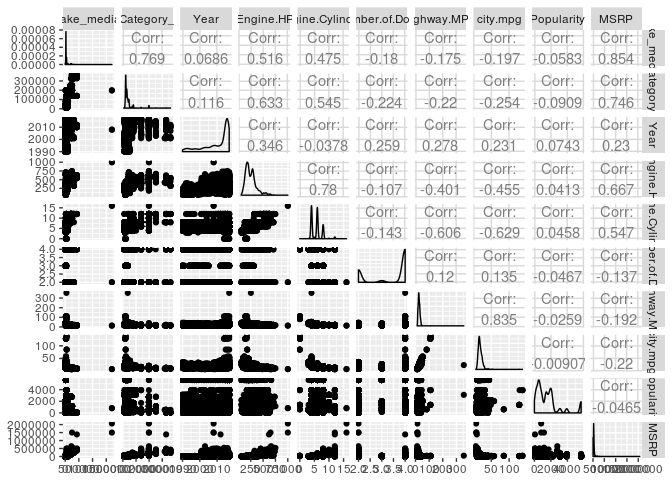

```r
train_data %>%
  ggpairs()
```

## Define função para calcular similaridade e média dos preços dos vizinhos mais próximos

O código abaixo define uma função que é responsável por calcular a média dos k vizinhos, do conjunto de treino passado como parâmetro, mais similares paca cada observação do conjunto de teste também passado como parâmetro.

```r
## Lista de colunas que são features para o treino
colunas <- colnames(train_data %>% select(-MSRP))

## Número de features
n_colunas <- length(colunas)

## Peso de cada feature para o cálculo de similaridade
pesos <- c(10, 10, 5, 8, 7, 2, 2, 1, 1)

determina_preco_medio <- function(treino, teste) {

  resultado_teste <- data.frame()
  local_similaridade <- treino

  ## Executa em todas as linhas do conjunto de teste
  for(j in 1:nrow(teste)) {

    ## Seleciona a linha/observacao corrente no laço
    observacao <- as.vector(as.numeric(teste[j,]))
    ID_j <- observacao[1]

    ## Calcula a similaridade da observação com relação a todos os casos do conjunto de treino para todas as features
    for (i in 1:n_colunas) {
      temp <- treino %>%
        mutate(range = max(get(colunas[i])) - min(get(colunas[i]))) %>%
        mutate(sim = (range - abs(get(colunas[i]) - observacao[i+1])) / range) %>%
        mutate(w_sim = sim * pesos[i]) %>%
        select(w_sim)

      local_similaridade <- local_similaridade %>% cbind(temp)
    }

    ## Seleciona todas as similaridades locais calculadas para a linha/observação corrente
    similaridade <- local_similaridade[tail(seq_along(local_similaridade),n_colunas+1)]

    ## Calcular a similaridade global como a soma das similaridades locais dividida pela soma dos pesos definidos
    similaridade$global <- rowSums(similaridade %>% select(-MSRP)) / sum(pesos)

    ## Seleciona os 10 casos com maior similaridade com relação a linha/observação corrente
    similaridade_k <- similaridade %>%
      arrange(desc(global)) %>%
      slice(1:10) %>%
      mutate(id = ID_j)

    ## Renomeia as colunas e calcula a média dos preços dos k vizinhos mais similares a linha/observação corrente. Sendo k variando de 1 a 10.
    res <- as.data.frame(t(observacao)) %>%
      select(id = V1, Make_median = V2, Market.Category_median = V3, Year = V4, Engine.HP = V5, Engine.Cylinders = V6, Number.of.Doors = V7,
             highway.MPG = V8, city.mpg = V9, Popularity = V10, MSRP = V11) %>%
      cbind(media1 = mean((similaridade_k %>% slice(1:1))$MSRP)) %>%
      cbind(media2 = mean((similaridade_k %>% slice(1:2))$MSRP)) %>%
      cbind(media3 = mean((similaridade_k %>% slice(1:3))$MSRP)) %>%
      cbind(media4 = mean((similaridade_k %>% slice(1:4))$MSRP)) %>%
      cbind(media5 = mean((similaridade_k %>% slice(1:5))$MSRP)) %>%
      cbind(media6 = mean((similaridade_k %>% slice(1:6))$MSRP)) %>%
      cbind(media7 = mean((similaridade_k %>% slice(1:7))$MSRP)) %>%
      cbind(media8 = mean((similaridade_k %>% slice(1:8))$MSRP)) %>%
      cbind(media9 = mean((similaridade_k %>% slice(1:9))$MSRP)) %>%
      cbind(media10 = mean((similaridade_k %>% slice(1:10))$MSRP))

    ## Concatena o resultado da linha/observação corrente ao dataframe do resultado final
    resultado_teste <- resultado_teste %>%
      rbind(res)

    ## Reinicia treino para a pŕoxima linha/observação corrente
    local_similaridade <- treino
  }

  return(resultado_teste)
}
```

## Estima médias de preço para o conjunto de validação

Agora vamos utilizar a função para criar um dataframe que possua os resultados finais para o o conjunto de validação definido acima.

```r
final <- determina_preco_medio(train_data, validation_data %>% tibble::rowid_to_column("id"))
```

A seguir vamos definir uma medida de erro como sendo o quadrado da diferença entre o preço estimado e o preço real do carro, para o conjunto de validação.

```r
evaluate_validation_result <- final %>%
  select(MSRP, media1, media2, media3, media4, media5, media6, media7, media8, media9, media10) %>%
  mutate(erro1 = (MSRP - media1)^2) %>%
  mutate(erro2 = (MSRP - media2)^2) %>%
  mutate(erro3 = (MSRP - media3)^2) %>%
  mutate(erro4 = (MSRP - media4)^2) %>%
  mutate(erro5 = (MSRP - media5)^2) %>%
  mutate(erro6 = (MSRP - media6)^2) %>%
  mutate(erro7 = (MSRP - media7)^2) %>%
  mutate(erro8 = (MSRP - media8)^2) %>%
  mutate(erro9 = (MSRP - media9)^2) %>%
  mutate(erro10 = (MSRP - media10)^2)
```

Para cada k, de 1 a 10, é calculada a soma acumulada dos erros para cada observação do conjunto de validação.

```r
validation_errors <- data_frame(1, sum(evaluate_validation_result$erro1)) %>%
  rbind(c(2, sum(evaluate_validation_result$erro2))) %>%
  rbind(c(3, sum(evaluate_validation_result$erro3))) %>%
  rbind(c(4, sum(evaluate_validation_result$erro4))) %>%
  rbind(c(5, sum(evaluate_validation_result$erro5))) %>%
  rbind(c(6, sum(evaluate_validation_result$erro6))) %>%
  rbind(c(7, sum(evaluate_validation_result$erro7))) %>%
  rbind(c(8, sum(evaluate_validation_result$erro8))) %>%
  rbind(c(9, sum(evaluate_validation_result$erro9))) %>%
  rbind(c(10, sum(evaluate_validation_result$erro10)))

colnames(validation_errors) <- c("k", "soma_erros")
```

Esse é o resultado final apresentado por k. Podemos concluir que para o conjunto de treino e validação utilizados, considerando os pesos que foram determinados e a métrica definida o resultado por k, que varia de 1 a 10, mostra que o melhor valor de k é 3. Ou seja, se os 3 vizinhos mais próximos forem considerados para a estimação do preço os resultados são os melhores.

```r
kable(validation_errors %>%
        arrange(soma_erros),
      col.names = c("k", "Soma dos erros"),
      align = "cc")
```

| k | Soma dos erros |
| --- | --- |
| 3 | 1616654982427 |
| 4 | 1682423725240 |
| 6 | 1751811129968 |
| 5 | 1858974802690 |
| 1 | 1894205839469 |
| 7 | 1922130196455 |
| 8 | 1998057430580 |
| 2 | 2077170265593 |
| 9 | 2112610463821 |
| 10 | 2197236919447 |